title: “Reproducible Research: Peer Assessment 1” Kenneth Richlin output: html_document: keep_md: true

## Loading and preprocessing the data

```r
setwd("~/GitHub/RepData_PeerAssessment1")

activityData <- read.csv(file = "activity.csv", sep =",", colClasses=c("integer","Date","integer"))
str(activityData)
```

```
## 'data.frame':    17568 obs. of  3 variables:
##  $ steps   : int  NA NA NA NA NA NA NA NA NA NA ...
##  $ date    : Date, format: "2012-10-01" "2012-10-01" ...
##  $ interval: int  0 5 10 15 20 25 30 35 40 45 ...
```

```r
summary(activityData)
```

```
##      steps             date               interval
##  Min.   :  0.00   Min.   :2012-10-01   Min.   :   0.0
##  1st Qu.:  0.00   1st Qu.:2012-10-16   1st Qu.: 588.8
##  Median :  0.00   Median :2012-10-31   Median :1177.5
##  Mean   : 37.38   Mean   :2012-10-31   Mean   :1177.5
##  3rd Qu.: 12.00   3rd Qu.:2012-11-15   3rd Qu.:1766.2
##  Max.   :806.00   Max.   :2012-11-30   Max.   :2355.0
##  NA's   :2304
```

## What is mean total number of steps taken per day?

We can use tapply on the sum function to determine the mean number of steps taken per day.

```r
totalSteps <- tapply(activityData$steps, activityData$date, sum, na.rm=TRUE)
stepMean <- mean(totalSteps)
stepMean
```

```
## [1] 9354.23
```

```r
stepMedian <- median(totalSteps)
stepMedian
```

```
## [1] 10395
```

### Create a histogram of the total number of steps taken each day

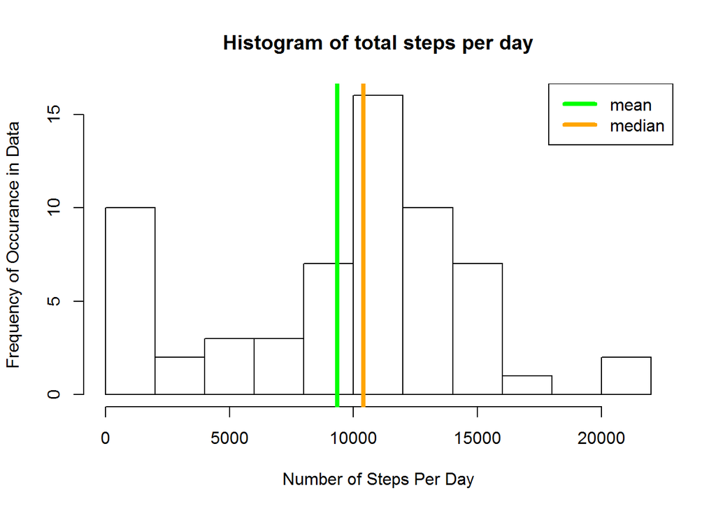

```r
hist(totalSteps, breaks = 12,
     xlab = "Number of Steps Per Day",
     ylab = "Frequency of Occurance in Data",
     main = "Histogram of total steps per day")

abline(v=stepMean, col="green", lwd ="4")
abline(v=stepMedian, col="orange", lwd ="4")
legend(x = "topright", legend = c("mean", "median"), col=c("green","orange"), lwd = 4)
```

### Calculate and report the mean and median of the total number of steps taken per day

The mean number of steps taken each day is: 9354.2295082. the median number of steps taken each day is: 10395.